# PW1

2022-09-15

#Part 1

Question1

```r
library("caTools")
```

Loads the package caTools

Question2

```r
dataset<-read.csv(file="E:\\ESILV\\S7\\Machine Learning\\PW\\PW1\\dataset.csv")
```

Loads the dataset

Question3

```r
View(dataset)
```

Views the loaded dataset

Question4

```r
dataset$Age=ifelse(is.na(dataset$Age),
                   mean(dataset$Age, na.rm=TRUE),
                   dataset$Age)

dataset$Salary=ifelse(is.na(dataset$Salary),
                   mean(dataset$Salary, na.rm=TRUE),
                   dataset$Salary)
```

Allows missing values to be replaced by the average of the other values

Question5

```r
dataset$Country=factor(dataset$Country,
                       levels=c('France','Spain','Germany'),
                       labels=c(1.0,2.0,3.0)
                       )
```

Allows country names (string) to be replaced by doubles to facilitate processing

Question6

```r
dataset$Purchased=factor(dataset$Purchased,
                         levels=c('No ','Yes'),
                         labels=c(0,1)
                         )
```

Does the same as the last question but with int (0,1)

Question7

```r
library("caTools")
set.seed(123)
split=sample.split(dataset$Purchased,SplitRatio=0.8)
training_set=subset(dataset,split==TRUE)
test_set=subset(dataset==FALSE)


training_set
```

```
##    Country      Age   Salary Purchased
## 1        1 44.00000 72000.00         0
## 2        2 27.00000 48000.00         1
## 3        3 30.00000 54000.00         0
## 4        2 38.00000 61000.00         0
## 5        3 40.00000 63777.78         1
## 7        2 38.77778 52000.00         0
## 8        1 48.00000 79000.00         1
## 10       1 37.00000 67000.00         1
```

Allows to separate the dataset in 2 parts: training set and test set, with a separation ratio of 80% for training set and 20% for test set

Question8

```r
training_set[,2:3]=scale(training_set[,2:3])
test_set[,2:3]=scale(test_set[,2:3])

View(training_set)
View(test_set)
```

Allows to scale the both dataset then we can work on it and views them

#First machine learning project

Question 1

```r
data(iris)
dataset2<-iris
View(iris)
```

Loads the dataset “iris” from R.studio and views it

```r
dim(dataset2)
```

```
## [1] 150   5
```

Gives us the dimension of the dataset

Question 2

```r
library(caret)
validation_index=createDataPartition(dataset2$Species,p = 0.8, list = FALSE)
validation=dataset2[-validation_index,]
dataset2=dataset2[validation_index,]

dim(dataset2)
```

```
## [1] 120   5
```

Loads the “caret” package and split the dataset into 2 parts: training set and validation set but with another way than before Shows the dimension of the dataset

Question 3

```r
sapply(dataset2,class)
```

```
## Sepal.Length  Sepal.Width Petal.Length  Petal.Width      Species
##    "numeric"    "numeric"    "numeric"    "numeric"     "factor"
```

```r
summary(dataset2)
```

```
##   Sepal.Length    Sepal.Width     Petal.Length    Petal.Width
##  Min.   :4.300   Min.   :2.200   Min.   :1.000   Min.   :0.100
##  1st Qu.:5.100   1st Qu.:2.800   1st Qu.:1.600   1st Qu.:0.300
##  Median :5.750   Median :3.000   Median :4.200   Median :1.300
##  Mean   :5.817   Mean   :3.033   Mean   :3.743   Mean   :1.185
##  3rd Qu.:6.400   3rd Qu.:3.300   3rd Qu.:5.100   3rd Qu.:1.800
##  Max.   :7.900   Max.   :4.100   Max.   :6.700   Max.   :2.500
##        Species
##  setosa    :40
##  versicolor:40
##  virginica :40
##
##
##
```

```r
levels(dataset2$Species)
```

```
## [1] "setosa"     "versicolor" "virginica"
```

```r
head(dataset2)
```

```
##   Sepal.Length Sepal.Width Petal.Length Petal.Width Species
## 1          5.1         3.5          1.4         0.2  setosa
## 2          4.9         3.0          1.4         0.2  setosa
## 5          5.0         3.6          1.4         0.2  setosa
## 6          5.4         3.9          1.7         0.4  setosa
## 7          4.6         3.4          1.4         0.3  setosa
## 8          5.0         3.4          1.5         0.2  setosa
```

Allows to apply the function “class” to the dataset (sapply()) Summarizes the main informations of the dataset (summary()) Returns the levels value of the dataset’s species (levels()) Shows the head of the dataset (head())

Question 5

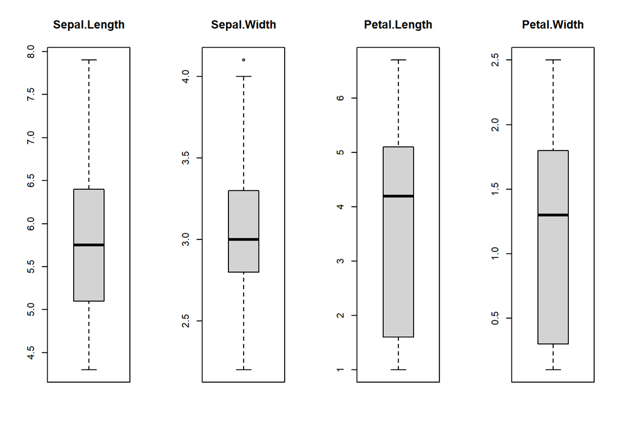

```r
x<-dataset2[,1:4]
y<-dataset2[,5]

par(mfrow=c(1,4))
  for(i in 1:4){
    boxplot(x[,i], main=names(iris)[i])
  }
```

Plots the boxplots of the different variables x are the variables (lenghts…) and y is the different species

Question 6

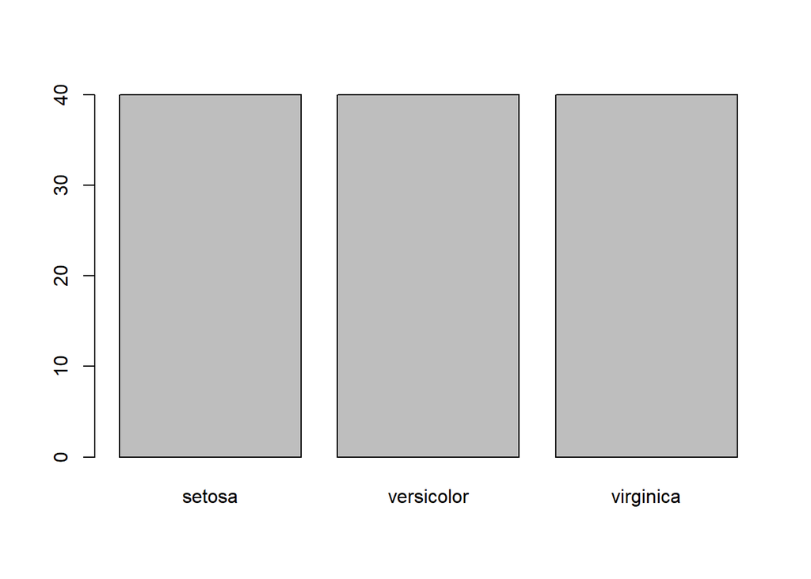

```r
plot(y)
```

Plots the number of the different individuals

Question 7

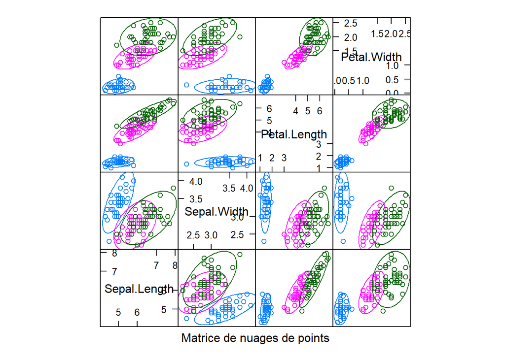

```r
featurePlot(x=x,y=y,plot="ellipse")
```

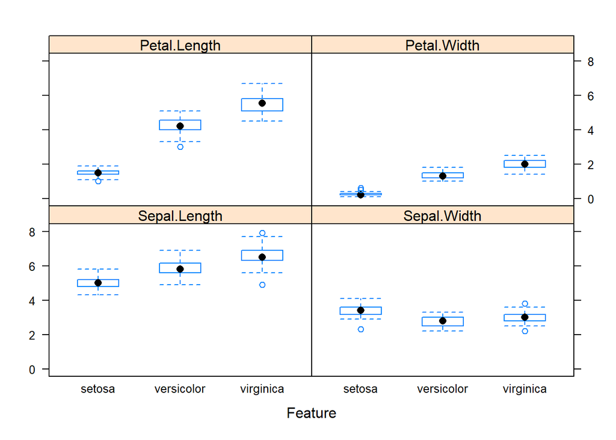

```r
featurePlot(x=x,y=y,plot="box")
```

Shows the matrix correlation between the different variables The second plot shows the boxplots of the variables depending on the species

Question 8

```r
control<-trainControl(method="cv",number=10)
metric<-"Accuracy"
```

Controls the computational nuances of the train function with the “cv” method

Question 9

#Model KNN

```r
set.seed(123)
fit.knn<-train(Species~. , data=dataset2, method="knn", metric=metric, trControl=control)
print(fit.knn)
```

```
## k-Nearest Neighbors
##
## 120 samples
##   4 predictor
##   3 classes: 'setosa', 'versicolor', 'virginica'
##
## No pre-processing
## Resampling: Cross-Validated (10 fold)
## Summary of sample sizes: 108, 108, 108, 108, 108, 108, ...
## Resampling results across tuning parameters:
##
##   k  Accuracy   Kappa
##   5  0.9583333  0.9375
##   7  0.9750000  0.9625
##   9  0.9666667  0.9500
##
## Accuracy was used to select the optimal model using the largest value.
## The final value used for the model was k = 7.
```

Sets up a grid with different informations for different models (here: KNN) and measure the “fit” of the model

#Model Support Vector Machines

```r
set.seed(123)
fit.svm<-train(Species~. , data=dataset2, method="svmLinear", metric=metric, trControl=control)
print(fit.svm)
```

```
## Support Vector Machines with Linear Kernel
##
## 120 samples
##   4 predictor
##   3 classes: 'setosa', 'versicolor', 'virginica'
##
## No pre-processing
## Resampling: Cross-Validated (10 fold)
## Summary of sample sizes: 108, 108, 108, 108, 108, 108, ...
## Resampling results:
##
##   Accuracy   Kappa
##   0.9666667  0.95
##
## Tuning parameter 'C' was held constant at a value of 1
```

Sets up a grid for the “SVMLinear” model

#Model Random Forest

```r
set.seed(123)
fit.rf<-train(Species~. , data=dataset2, method="rf", metric=metric, trControl=control)
print(fit.rf)
```

```
## Random Forest
##
## 120 samples
##   4 predictor
##   3 classes: 'setosa', 'versicolor', 'virginica'
##
## No pre-processing
## Resampling: Cross-Validated (10 fold)
## Summary of sample sizes: 108, 108, 108, 108, 108, 108, ...
## Resampling results across tuning parameters:
##
##   mtry  Accuracy   Kappa
##   2     0.9666667  0.9500
##   3     0.9583333  0.9375
##   4     0.9583333  0.9375
##
## Accuracy was used to select the optimal model using the largest value.
## The final value used for the model was mtry = 2.
```

Sets up a grid for the “RF” model

Question 10

```r
results <- resamples(list(knn=fit.knn, svm=fit.svm, rf=fit.rf))
summary(results)
```

```
##
## Call:
## summary.resamples(object = results)
##
## Models: knn, svm, rf
## Number of resamples: 10
##
## Accuracy
##          Min.   1st Qu. Median      Mean 3rd Qu. Max. NA's
## knn 0.9166667 0.9375000      1 0.9750000       1    1    0
## svm 0.9166667 0.9166667      1 0.9666667       1    1    0
## rf  0.9166667 0.9166667      1 0.9666667       1    1    0
##
## Kappa
##      Min. 1st Qu. Median   Mean 3rd Qu. Max. NA's
## knn 0.875 0.90625      1 0.9625       1    1    0
## svm 0.875 0.87500      1 0.9500       1    1    0
## rf  0.875 0.87500      1 0.9500       1    1    0
```

Gives us the results of the differents models

Question 11

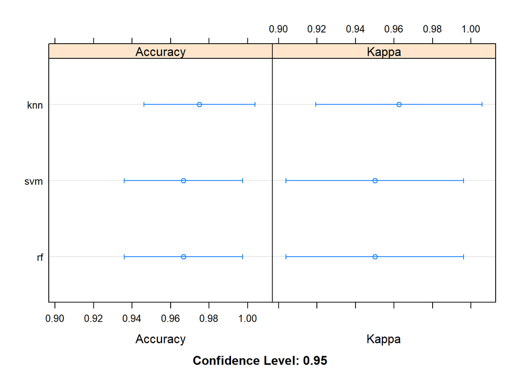

```r
dotplot(results)
```

Plots the last results

Question 12

```r
predictions <- predict(fit.knn, validation)
confusionMatrix(predictions, validation$Species)
```

```
## Confusion Matrix and Statistics
##
##             Reference
## Prediction   setosa versicolor virginica
##   setosa         10          0         0
##   versicolor      0          9         1
##   virginica       0          1         9
##
## Overall Statistics
##
##                Accuracy : 0.9333
##                  95% CI : (0.7793, 0.9918)
##     No Information Rate : 0.3333
##     P-Value [Acc > NIR] : 8.747e-12
##
##                   Kappa : 0.9
##
##  Mcnemar's Test P-Value : NA
##
## Statistics by Class:
##
##                      Class: setosa Class: versicolor Class: virginica
## Sensitivity                 1.0000            0.9000           0.9000
## Specificity                 1.0000            0.9500           0.9500
## Pos Pred Value              1.0000            0.9000           0.9000
## Neg Pred Value              1.0000            0.9500           0.9500
## Prevalence                  0.3333            0.3333           0.3333
## Detection Rate              0.3333            0.3000           0.3000
## Detection Prevalence        0.3333            0.3333           0.3333
## Balanced Accuracy           1.0000            0.9250           0.9250
```